LABORATORIUM 7

- Korelacje Pearsona i Spearmana
- Test $\chi^2$ Pearsona dla macierzy kontyngencji
- Regresja liniowa
- Wielokrotna regresja liniowa
- Binowanie

#### **Korelacje Pearsona i Spearmana**

Popularną miarą zależności pomiędzy dwiema zmiennym jest **współczynnik korelacji Pearsona**, zdefiniowany (populacyjnie) dla dwóch zmiennych losowych $X$ i $Y$ jako

$r_{XY} = \frac{\mathrm{cov}(X,Y)}{\sigma_X \sigma_Y}$,

natomiast w przypadku estymatora próbkowego dla serii $n$ danych $x_i$ oraz $y_i$ jako

$r = \frac{\sum_{i=1}^n(x_i-\bar{x})(y_i-\bar{y})}{\sqrt{\sum_{i=1}^n(x_i - \bar{x})^2}\sqrt{\sum_{i=1}^n(y_i - \bar{y})^2}}$.

Współczynnik można łatwo obliczyć w R przy pomocy funkcji `cor()`.

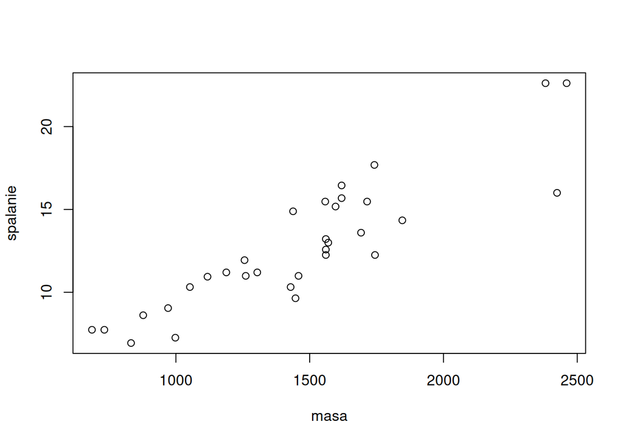

```r
lb2kg <- 0.4536
gallons2liter <- 3.78541178
miles2km <- 1.609344

masa <- 1000*lb2kg*mtcars$wt # masa pojazdu (w kg)
spalanie <- 100*gallons2liter/(mtcars$mpg*miles2km) # spalanie (w litrach na 100 km)
plot (masa, spalanie)
```

```r
cor (masa, spalanie)
```

```
## [1] 0.8898927
```

W przypadku, gdy mamy do czynienia z korelacją rang, używa się **współczynnika Spearmana** `cor(method="spearman")`, który jest de facto współcznnikiem Pearsona dla danych przekształconych w rangi.

```r
cor (masa, spalanie, method="spearman")
```

```
## [1] 0.886422
```

```r
masa
```

```
##  [1] 1188.4320 1304.1000 1052.3520 1458.3240 1560.3840 1569.4560 1619.3520
##  [8] 1446.9840 1428.8400 1560.3840 1560.3840 1846.1520 1691.9280 1714.6080
## [15] 2381.4000 2460.3264 2424.4920  997.9200  732.5640  832.3560 1118.1240
## [22] 1596.6720 1558.1160 1741.8240 1744.0920  877.7160  970.7040  686.2968
## [29] 1437.9120 1256.4720 1619.3520 1261.0080
```

```r
rank(masa)
```

```
##  [1]  9.0 12.0  7.0 16.0 19.0 21.0 23.5 15.0 13.0 19.0 19.0 29.0 25.0 26.0 30.0
## [16] 32.0 31.0  6.0  2.0  3.0  8.0 22.0 17.0 27.0 28.0  4.0  5.0  1.0 14.0 10.0
## [31] 23.5 11.0
```

```r
spalanie
```

```
##  [1] 11.200694 11.200694 10.316429 10.991336 12.578320 12.995281 16.448572
##  [8]  9.639942 10.316429 12.250760 13.214302 14.342353 13.596219 15.474644
## [15] 22.616787 22.616787 16.000992  7.259709  7.737322  6.938483 10.940213
## [22] 15.175134 15.474644 17.685307 12.250760  8.615919  9.046715  7.737322
## [29] 14.886999 11.939827 15.680972 10.991336
```

```r
rank(spalanie)
```

```
##  [1] 13.5 13.5  8.5 11.5 18.0 19.0 29.0  7.0  8.5 16.5 20.0 22.0 21.0 25.5 31.5
## [16] 31.5 28.0  2.0  3.5  1.0 10.0 24.0 25.5 30.0 16.5  5.0  6.0  3.5 23.0 15.0
## [31] 27.0 11.5
```

```r
cor (rank (masa), rank (spalanie))
```

```
## [1] 0.886422
```

Jeśli funkcji `cor()` przekażemy ramkę danych, zostaną wyliczone współczynniki korelacji pomiędzy każdą parą zmiennych i przedstawione w posteci macierzy

```r
df <- data.frame (masa = masa, spalanie = spalanie, czas = mtcars$qsec)
cor (df)
```

```
##                masa   spalanie       czas
## masa      1.0000000  0.8898927 -0.1747159
## spalanie  0.8898927  1.0000000 -0.3858480
## czas     -0.1747159 -0.3858480  1.0000000
```

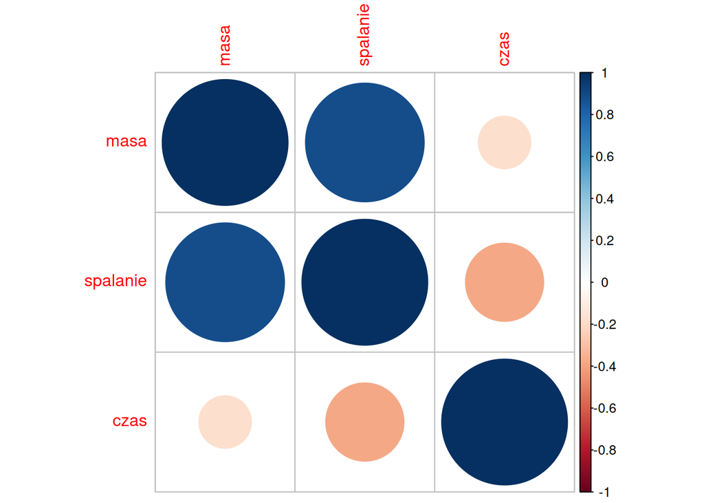

```r
library(corrplot)
corrplot (cor(df))
```

W celu otrzymania pełnych informacji, dotyczących parametrów współczynnika korelacji należy użyć funkcji `cor.test()`

```r
cor.test (masa, spalanie)
```

```
##
##  Pearson's product-moment correlation
##
## data:  masa and spalanie
## t = 10.685, df = 30, p-value = 9.566e-12
## alternative hypothesis: true correlation is not equal to 0
## 95 percent confidence interval:
##  0.7846874 0.9452694
## sample estimates:
##       cor
## 0.8898927
```

W powyższym przypadku p-wartość (*p-value*) testu jest bardzo mała, zatem możemy odrzucić hipotezę zerową mówiącą, że korelacja pomiędzy zmiennymi jest równa zero. Należy pamiętać, że korelacja Pearsona mierzy zależność liniową między dwiema zmiennymi i jest nieczuła na zależności niemonotoniczne (na przykład kwadratową).

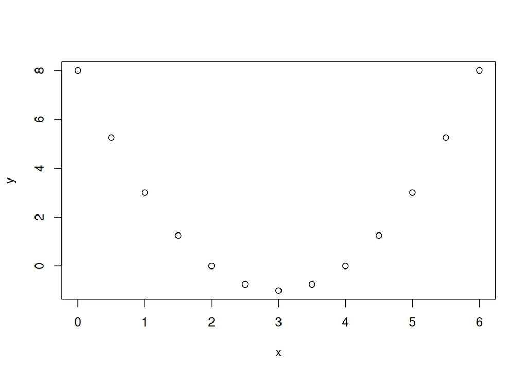

```r
x <- seq(0,6,0.5)
y <- x^2-6*x+8
plot(x, y)
```

```r
cor.test (x,y)
```

```
##
##  Pearson's product-moment correlation
##
## data:  x and y
## t = 0, df = 11, p-value = 1
## alternative hypothesis: true correlation is not equal to 0
## 95 percent confidence interval:
##  -0.5509853  0.5509853
## sample estimates:
## cor
##   0
```

#### **Test $\chi^2$ Pearsona dla macierzy kontyngencji**

W przypadku, gdy mamy do czynienia z dwiema zmiennymi jakościowymi i chcemy sprawdzić czy występują one niezależnie, możemy wykonać test $\chi^2$ Pearsona, wywoływany funkcją `chisq.test()`

```r
biegi <- factor (mtcars$am, labels = c("automatic","manual"))
cylindry <- factor (mtcars$cyl)
tab <- table (biegi, cylindry)
tab
```

```
##            cylindry
## biegi        4  6  8
##   automatic  3  4 12
##   manual     8  3  2
```

```r
chisq.test(tab)
```

```
##
##  Pearson's Chi-squared test
##
## data:  tab
## X-squared = 8.7407, df = 2, p-value = 0.01265
```

Niska p-wartość wskazuje, że należy odrzucić hipotezę zerową o niezależności zmiennych. Można sprawdzić jak wyglądałaby macierz wartości oczekiwanych (i prawdopodobieństwa) w przypadku zmiennych niezależnych i sprawdzić, czy jest ona równa iloczynom rozkładów brzegowych.

```r
tab.exp <- chisq.test(tab)$expected
tab.exp
```

```
##            cylindry
## biegi             4       6      8
##   automatic 6.53125 4.15625 8.3125
##   manual    4.46875 2.84375 5.6875
```

```r
tab.exp / sum(tab.exp)
```

```
##            cylindry
## biegi               4          6         8
##   automatic 0.2041016 0.12988281 0.2597656
##   manual    0.1396484 0.08886719 0.1777344
```

Powyższa tabela mówi o tym, jakie powinny być prawdopodobieństwa wystąpienia danej pary, jeśli zmienne byłyby niezależne, czyli występowały losowo. Wartości te można wyznaczyć z naszej oryginalnej tabeli obliczając rozkłady brzegowe

```r
tab.biegi <- apply(tab, 1, sum) / sum(tab)
tab.cylindry <- apply(tab, 2, sum) / sum(tab)
tab.biegi %o% tab.cylindry
```

```
##                   4          6         8
## automatic 0.2041016 0.12988281 0.2597656
## manual    0.1396484 0.08886719 0.1777344
```

Natomiast faktyczne wartości prawdopodobieństw, otrzymane po prostu poprzez podzielenie poszczególnych zliczeń przez całkowitą liczbę przypadków są zupełnie inne, co potwierdza wynik testu.

```r
tab / sum(tab)
```

```
##            cylindry
## biegi             4       6       8
##   automatic 0.09375 0.12500 0.37500
##   manual    0.25000 0.09375 0.06250
```

#### **Regresja liniowa**

Samo stwierdzenie korelacji liniowej między dwiema zmiennymi jest czasem niewystarczające i chcielibyśmy znaleźć pomiędzy nimi zależność funkcyjną po to aby móć przewidywać wartości jednej zmiennej na podstawie drugiej. Jeśli korelacja Pearsona jest wysoka, odpowiednim modelem może być regresja liniowa. W pakiecie R jest ona zaimplementowana poprzez funkcję `lm()`, przy czym specyficzny jest sposób wprowadzania formuły - w R wykorzystuje się symbol tyldy `~` do pokazania zależności pomiędzy zmiennymi (np. `y ~ x` oznacza zależność pomiędzy x i y. Poniżej generujemy zaburzoną losowo zależność liniową:

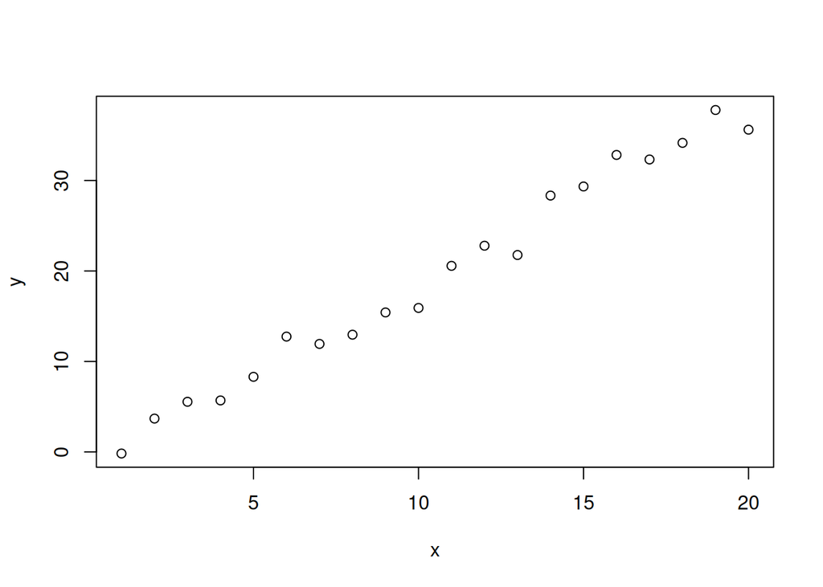

```r
x <- 1:20
y <- 2*x-2 + runif(length(x), -3, 3)
plot(x, y)
```

Wykonujemy regresję liniową i wynik procedury zapisujemy do zmiennej `xy.lm`. Po wywołaniu funkcji `summary()` otrzymamy wszystkie interesujące nas wartości dotyczące regresji, w szczególności p-wartości (kolumna `Pr(>|t|)` oraz ostatnia linijka `summary`) informujące nas czy dopasowanie modelu liniowego jest statystycznie uzasadnione. Hipoteza zerowa testu głosi, że prawdziwa wartość współczynnika wynosi zero, a więc zależność liniowa nie istnieje.

```r
xy.lm <- lm(y ~ x)
summary(xy.lm)
```

```
##
## Call:
## lm(formula = y ~ x)
##
## Residuals:
##      Min       1Q   Median       3Q      Max
## -2.61645 -0.83226 -0.03008  1.08465  2.53062
##
## Coefficients:
##             Estimate Std. Error t value Pr(>|t|)
## (Intercept) -1.46228    0.74223   -1.97   0.0644 .
## x            1.98475    0.06196   32.03   <2e-16 ***
## ---
## Signif. codes:  0 '***' 0.001 '**' 0.01 '*' 0.05 '.' 0.1 ' ' 1
##
## Residual standard error: 1.598 on 18 degrees of freedom
## Multiple R-squared:  0.9828, Adjusted R-squared:  0.9818
## F-statistic:  1026 on 1 and 18 DF,  p-value: < 2.2e-16
```

Widoczny jest również współczynnik $R^2$ będący równy kwadratowi korelacji Pearsona pomiędzy zmiennymi.

```r
cor (x,y)^2
```

```
## [1] 0.9827602
```

Bezpośrednie odwołanie do współczynników otrzymujemy poprzez pole `coefficients`, przy czym `coefficients[1]` to punkt przecięcia, a `coefficients[2]`, to współczynnik kierunkowy. Możemy następnie zapisać współczynniki i wykreślić prostą dopasowania.

```r
xy.lm$coefficients
```

```
## (Intercept)           x
##   -1.462283    1.984755
```

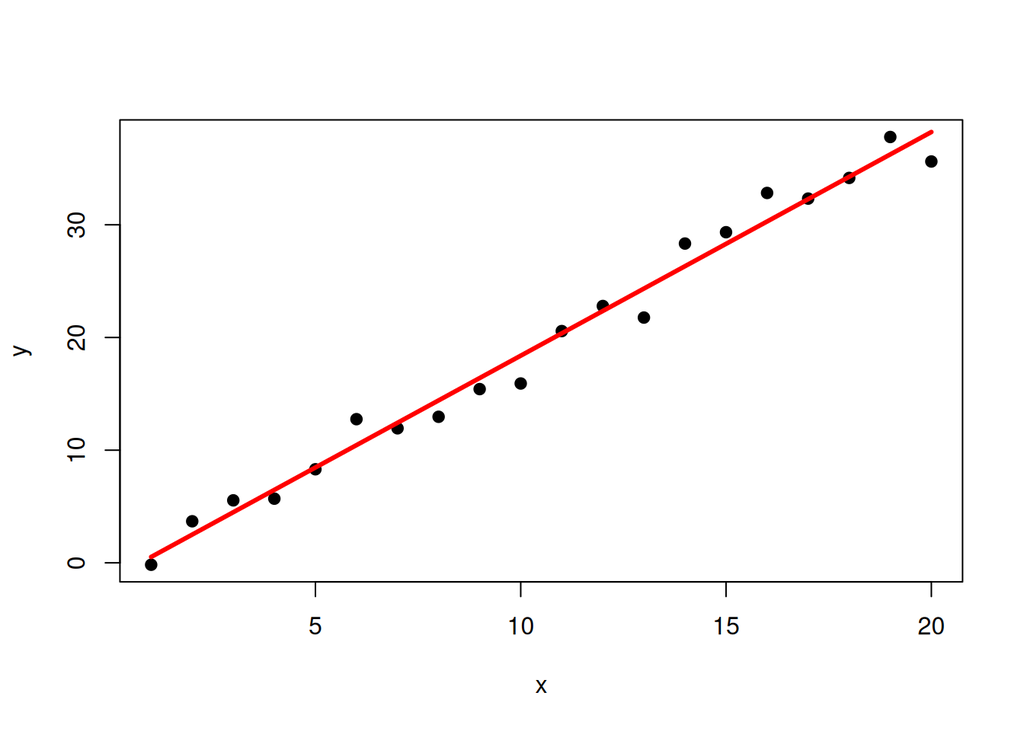

```r
b <- xy.lm$coefficients[1]
a <- xy.lm$coefficients[2]
plot(x, y, pch=19)
lines(x, a*x+b, col="red", lwd=3)
```

Podobną procedurę można przeprowadzić dla przetransformowanych zmiennych. Tutaj jest to zrandomiznowana zależność $y \sim x^{-2}$

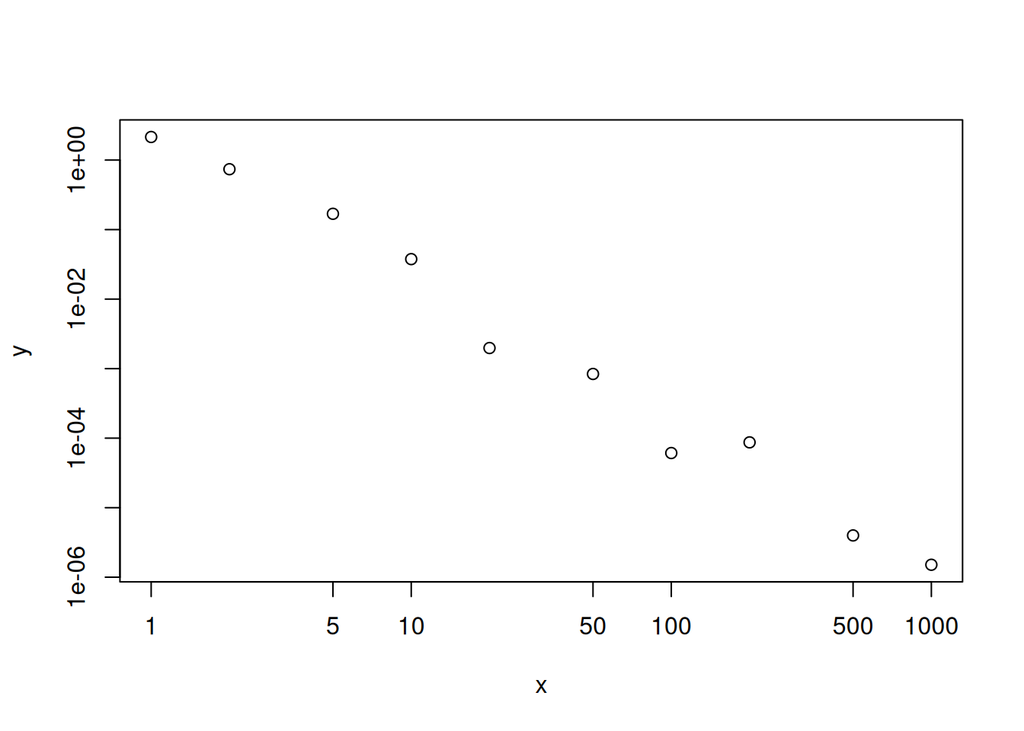

```r
x <- c(1,2,5,10,20,50,100,200,500,1000)
y <- (x*(1+runif(length(x),-0.9,0.9)))^(-2)
plot(x, y, log="xy")
```

```r
xy.lm <- lm(log(y) ~ log(x))
summary(xy.lm)
```

```
##
## Call:
## lm(formula = log(y) ~ log(x))
##
## Residuals:
##     Min      1Q  Median      3Q     Max
## -0.9748 -0.2969  0.1374  0.4682  0.8531
##
## Coefficients:
##             Estimate Std. Error t value Pr(>|t|)
## (Intercept)  1.06689    0.38325   2.784   0.0238 *
## log(x)      -2.12706    0.09343 -22.767 1.47e-08 ***
## ---
## Signif. codes:  0 '***' 0.001 '**' 0.01 '*' 0.05 '.' 0.1 ' ' 1
##
## Residual standard error: 0.6538 on 8 degrees of freedom
## Multiple R-squared:  0.9848, Adjusted R-squared:  0.9829
## F-statistic: 518.3 on 1 and 8 DF,  p-value: 1.469e-08
```

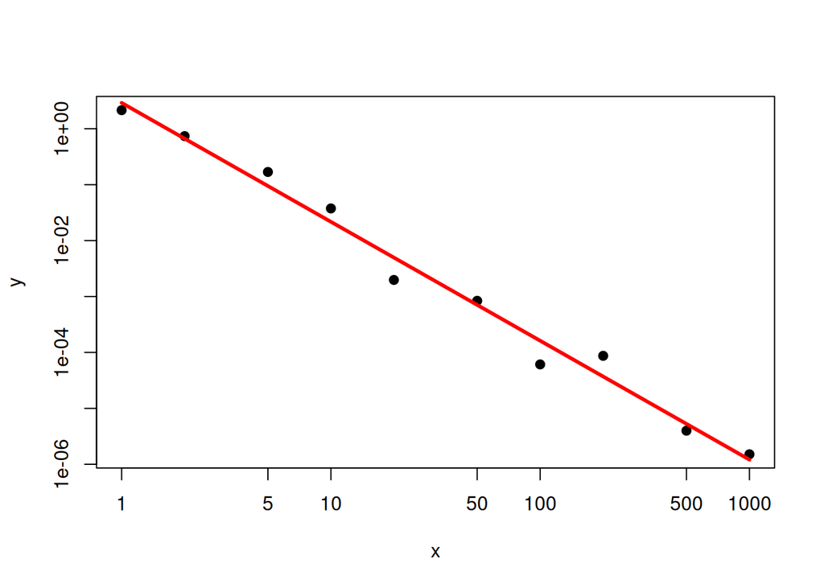

```r
b <- exp(xy.lm$coefficients[1])
a <- xy.lm$coefficients[2]
plot(x, y, pch=19, log="xy")
lines(x, b*x^a, col="red", lwd=3)
```

Zamiast samodzielnie przepisywać współczynniki modelu do wzoru, można skorzystać z uniwersalnej funkcji `predict`. Jej argumentami są obiekt zwrócony przez funkcję generującą model (w tym przypadku przez funkcję `lm()`) oraz ramka danych zawierająca kolumny ze zmiennymi wyjaśniającymi (czyli w tym przypadku argumentami funkcji liniowej). Funkcja zwraca wektor zmiennej wynikowej.

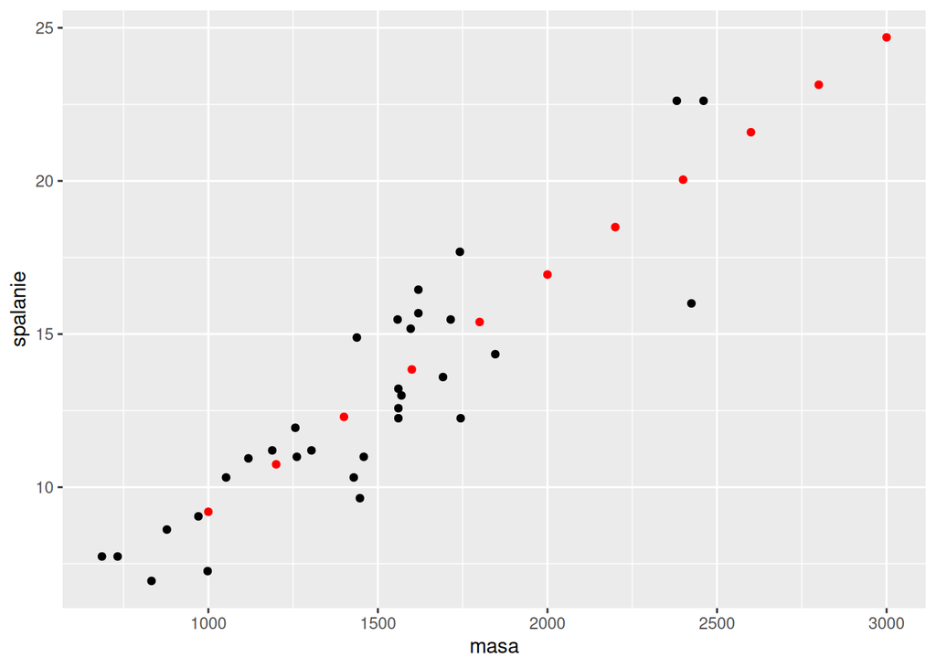

```r
# Jeszcze raz przykład ze zbioru mtcars
fit <- lm (spalanie ~ masa, data = df)
new.data <- data.frame (masa = seq(1e3,3e3,200))
new.data$spalanie <- predict (fit, new.data)

library(ggplot2)
ggplot(df, aes(x=masa, y=spalanie)) + geom_point () + geom_point (data=new.data, color="red")
```

#### **Wielokrotna regresja liniowa**

Czasami interesuje nas efekt wpływu kilku zmiennych wyjaśniających (predyktorów) na zmienną wynikową. Funkcja `lm` pozwala uwzględniać bardziej zaawansowane modele liniowe.

```r
df2 <- data.frame (spalanie=spalanie,
                   masa = masa,
                   cylindry = mtcars$cyl,
                   moc = mtcars$hp)

fit2 <- lm (spalanie ~ masa+cylindry+moc, data = df2)
summary (fit2)
```

```
##
## Call:
## lm(formula = spalanie ~ masa + cylindry + moc, data = df2)
##
## Residuals:
##     Min      1Q  Median      3Q     Max
## -3.7763 -1.1286  0.2647  0.9224  3.4531
##
## Coefficients:
##             Estimate Std. Error t value Pr(>|t|)
## (Intercept) 1.175743   1.124898   1.045   0.3049
## masa        0.005640   0.001028   5.487 7.34e-06 ***
## cylindry    0.189814   0.346823   0.547   0.5885
## moc         0.014824   0.007477   1.983   0.0573 .
## ---
## Signif. codes:  0 '***' 0.001 '**' 0.01 '*' 0.05 '.' 0.1 ' ' 1
##
## Residual standard error: 1.581 on 28 degrees of freedom
## Multiple R-squared:  0.8487, Adjusted R-squared:  0.8325
## F-statistic: 52.36 on 3 and 28 DF,  p-value: 1.322e-11
```

Należy zwrócić uwagę, że współcznynniki dopasowania, a także p-wartości są inne dla modelu z trzema zmiennymi wyjaśniającymi niż w modelach z jedną zmienną.

```r
summary (fit)
```

```
##
## Call:
## lm(formula = spalanie ~ masa, data = df)
##
## Residuals:
##     Min      1Q  Median      3Q     Max
## -4.2300 -1.0420  0.2214  1.0668  2.7422
##
## Coefficients:
##              Estimate Std. Error t value Pr(>|t|)
## (Intercept) 1.4510253  1.1043209   1.314    0.199
## masa        0.0077460  0.0007249  10.685 9.57e-12 ***
## ---
## Signif. codes:  0 '***' 0.001 '**' 0.01 '*' 0.05 '.' 0.1 ' ' 1
##
## Residual standard error: 1.791 on 30 degrees of freedom
## Multiple R-squared:  0.7919, Adjusted R-squared:  0.785
## F-statistic: 114.2 on 1 and 30 DF,  p-value: 9.566e-12
```

```r
fit3 <- lm (spalanie ~ moc, data = df2)
summary (fit3)
```

```
##
## Call:
## lm(formula = spalanie ~ moc, data = df2)
##
## Residuals:
##     Min      1Q  Median      3Q     Max
## -5.1694 -1.3342 -0.1650  0.5701  7.3550
##
## Coefficients:
##             Estimate Std. Error t value Pr(>|t|)
## (Intercept)  6.44908    1.07380   6.006 1.37e-06 ***
## moc          0.04299    0.00665   6.464 3.84e-07 ***
## ---
## Signif. codes:  0 '***' 0.001 '**' 0.01 '*' 0.05 '.' 0.1 ' ' 1
##
## Residual standard error: 2.539 on 30 degrees of freedom
## Multiple R-squared:  0.5821, Adjusted R-squared:  0.5682
## F-statistic: 41.79 on 1 and 30 DF,  p-value: 3.839e-07
```

Jeszcze bardziej zaawansowane modele liniowe zawierają interakcje pomiędzy zmiennymi, tzn. zależność zmiennej wynikowej od zmiennej wyjaśniającej $x_1$ zależy od innej zmiennej wyjaśniającej $x_2$. Funkcja `lm()` uwzględni wszystkie interakcje jeśli zastąpimy symbol `+` symbolem `*` w formule określającej zależności między zmiennymi. Jeśli interesuje nas tylko wybrana interakcja to użyjemy symbolu `:`.

```r
n  <- 100
x1 <- rnorm (n, 175, 7)
x2 <- rnorm (n, 30, 8)
x3 <- abs (rnorm (n, 60, 30))

y <- x1 + 2*x2 - 3*x3 + 4*x1*x2 - 5*x1*x3 + 6*x2*x3 + 10 + rnorm(n, 0, 0.5)

df3 <- data.frame (x1, x2, x3, y)
y.lm <- lm (y ~ x1*x2*x3, data=df3)
summary(y.lm)
```

```
##
## Call:
## lm(formula = y ~ x1 * x2 * x3, data = df3)
##
## Residuals:
##      Min       1Q   Median       3Q      Max
## -1.37070 -0.28841 -0.04113  0.29556  1.36747
##
## Coefficients:
##               Estimate Std. Error   t value Pr(>|t|)
## (Intercept)  4.741e-01  1.689e+01     0.028    0.978
## x1           1.054e+00  9.753e-02    10.805  < 2e-16 ***
## x2           2.466e+00  5.732e-01     4.302 4.22e-05 ***
## x3          -2.912e+00  2.376e-01   -12.254  < 2e-16 ***
## x1:x2        3.997e+00  3.301e-03  1211.117  < 2e-16 ***
## x1:x3       -5.000e+00  1.382e-03 -3617.570  < 2e-16 ***
## x2:x3        5.994e+00  8.243e-03   727.205  < 2e-16 ***
## x1:x2:x3     3.289e-05  4.766e-05     0.690    0.492
## ---
## Signif. codes:  0 '***' 0.001 '**' 0.01 '*' 0.05 '.' 0.1 ' ' 1
##
## Residual standard error: 0.497 on 92 degrees of freedom
## Multiple R-squared:      1,  Adjusted R-squared:      1
## F-statistic: 2.77e+10 on 7 and 92 DF,  p-value: < 2.2e-16
```

#### **Binowanie danych**

W wielu przypadkach konieczne lub pożądane jest dokonanie “binowania” danych, czyli podzielenia osi X na przedziały, a następnie wyliczenia wartości średnich w tych przedziałach. W R można do tego wykorzystać funkcję `stats.bin()` z biblioteki `fields`.

```r
x <- 1:100
y <- x + runif(length(x), -20, 20)

library(fields)
xy.sb <- stats.bin(x, y)
xy.sb
```

```
## $centers
##  [1]  5 15 25 35 45 55 65 75 85 95
##
## $breaks
##  [1]   0  10  20  30  40  50  60  70  80  90 100
##
## $stats
##                          1         2         3        4        5         6
## N              10.00000000 10.000000 10.000000 10.00000 10.00000 10.000000
## mean            7.25317689 17.214446 25.433181 40.05567 52.35593 56.542506
## Std.Dev.       10.92378670 12.745898 15.382417 11.07094 12.55683  8.128647
## min            -7.76874296 -3.004256  6.369716 21.69734 34.07812 48.752295
## Q1             -0.05940365 11.925628 12.042595 34.78428 42.23615 52.026420
## median          7.37443167 15.598860 26.364566 40.68288 54.91623 53.310000
## Q3             12.27068406 23.946013 39.981684 48.36903 63.85484 58.503497
## max            23.35498266 35.579893 42.217397 53.65601 66.32768 74.447162
## missing values  0.00000000  0.000000  0.000000  0.00000  0.00000  0.000000
##                       7        8          9        10
## N              10.00000 10.00000  10.000000  10.00000
## mean           67.89887 75.92682  87.166113  93.76524
## Std.Dev.       11.91043 13.38903   9.684964  10.37659
## min            49.07113 55.83131  65.093485  77.01145
## Q1             63.77615 68.78764  84.160423  86.40719
## median         66.59840 73.12299  87.636806  93.21785
## Q3             74.32660 82.47955  90.310291  99.84477
## max            88.90349 97.02975 100.834616 110.81194
## missing values  0.00000  0.00000   0.000000   0.00000
```

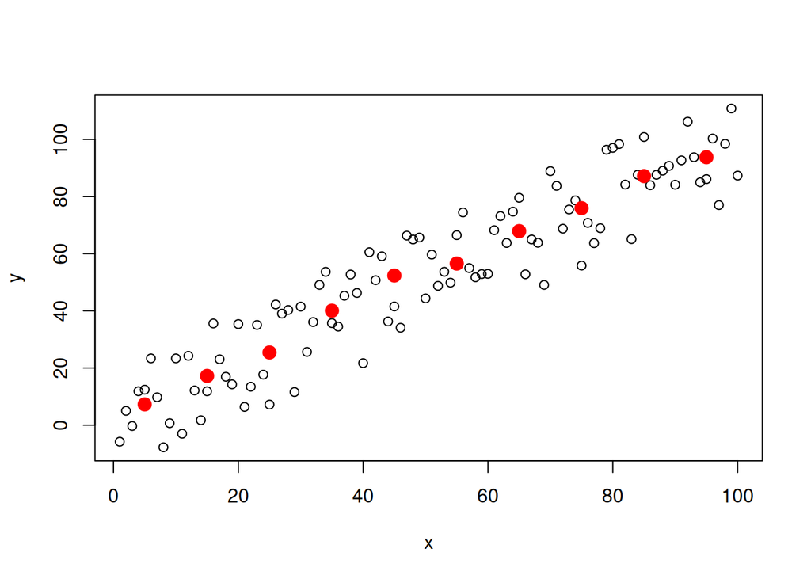

```r
plot (x, y)
points (xy.sb$centers, xy.sb$stats[2,], col="red", pch=19, cex=1.5)
```

Aby można było wykonać “przyzwoity” wykres z dopasowaniem liniowym, należałoby umieścić na nim także słupki błędów - można je dodać w pakiecie `ggplot2` przy pomocy funkcji `geom_errorbar()` lub `geom_pointrange()`.

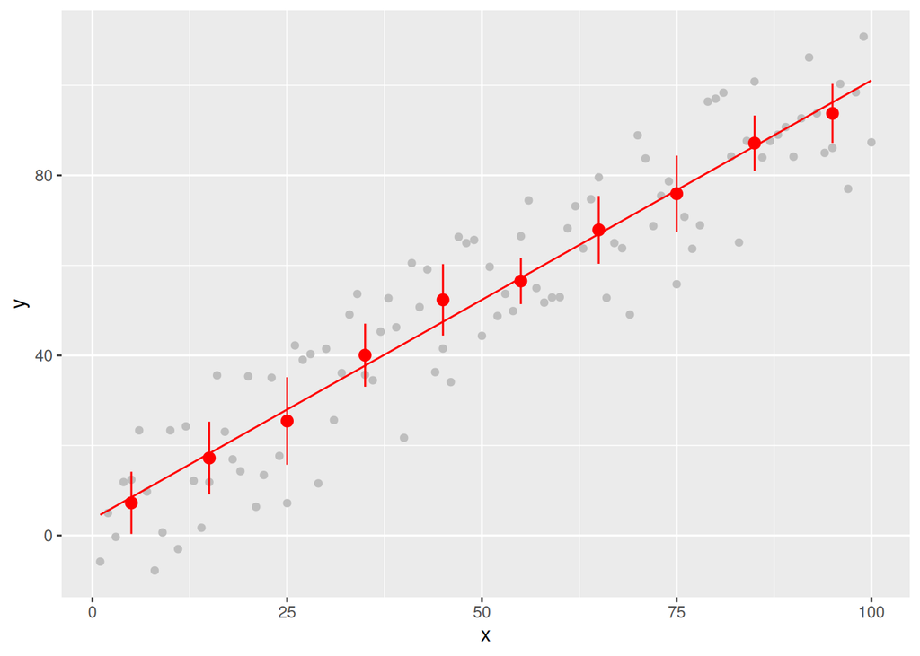

```r
library(dplyr)
library(magrittr)

df4 <- data.frame (x = x, y = y)
df5 <- data.frame (x = xy.sb$centers,
                   y = xy.sb$stats[2,],
                   sd = xy.sb$stats[3,],
                   n = xy.sb$stats[1,])

df5 %<>%
  mutate (std.err = 2*sd/sqrt(n))

xy.lm <- lm(y ~ x, data = df5)

my.lm <- function(x, model) {
  model$coefficients[2]*x+model$coefficients[1]
}

library(ggplot2)

ggplot(df4, aes (x = x, y = y)) +
  geom_point (color = "gray") +
  geom_pointrange(data=df5, aes (x = x, y = y, ymax = y+std.err, ymin = y-std.err), color="red") +
  stat_function(fun = my.lm, args = list (model = xy.lm), color="red")
```